# Template for Guide Documents

CRMDA Guide #40. Please visit http://crmda.ku.edu/guides for updates.

2016 November 21

Abstract

## In our KU css file, we have special highlighted elements for callouts.

Callout usage is demonstrated in the following. These are always preceeded by four # signs. Yes, ####. We stole this idea from other styles and put them into ours. See usage of {.bs-callout .bs-callout-whatever_you_put here}, where whatever_you_put_here is either “gray”, “red”, “orange”, “blue”, or “green”. We might be able to negotiate you you on the choice of colors. Run the render script with this document, you’ll see what we mean.

## Demonstrating Callouts

#### Policies about writing in these documents.

1. Use these callouts to attract attention
2. Blank rows separate paragraphs.
3. The character width of rows should be 80 or less. I have no idea how anybody thinks they have a right to impose an infinitely long row, but its bad. Edit the document with Emacs, run M-q to get repositioned text. If your editor cannot do that, quit using it.
4. Must make sure compiling using the kutils.css located in the crmda package e.g., `crmda::render2html("filename.Rmd")`

## You have the ability to include tabs

If you’d like, you can include different tabs. Maybe you want to show two similar versions of the same analysis. Or maybe something else. Whatever it may be, be sure to include `{.tabset .tabset-fade}` along with a level 2 header (##). For each tab, put the information under the level 3 header (###). Use another level 2 header to get out of the tabs mode.

The only way (that we know of) to get colors is to wrap the tab headers in a `<span style>` as shown below. This might be useful to draw attention to the tabs. Blue is the default color.

#### What it looks like

```
## You have the ability to include tabs {.tabset .tabset-fade}

If you'd like, you can include different tabs. Maybe you want to show two similar versions of the same analysis. Or maybe something else. Whatever it may be, be sure to include `{.tabset .tabset-fade}` along with a level 2 header (##). For each tab, put the information under the level 3 header (###)…

The only way (that we know of) to get colors is to wrap the tab headers in a `<span style>` as shown below. This might be useful to draw attention to the tabs. Blue is the default color.

### <span style="color:red">First Tab Here</span>

Some information you'd like to show.

### <span style="color:orange">Second Tab Here</span>

Some more information you'd like to show.

Some more information you'd like to show.

### Third Tab Here

Some final information you'd like to show.

Some final information you'd like to show.

Some final information you'd like to show.

## Equations can be written in LaTeX, either "inline" or "display" mode.
```

### First Tab Here

Some information you’d like to show.

### Second Tab Here

Some more information you’d like to show.

Some more information you’d like to show.

### Third Tab Here

Some final information you’d like to show.

Some final information you’d like to show.

Some final information you’d like to show.

## Equations can be written in LaTeX, either “inline” or “display” mode.

Equations can be introduced in the style of LaTeX. If the document is processed into a pdf file, the LaTeX programs will be used, but if the document is rendered to HTML, then symbolic questions are positioned into the output and then the MathJax javascript framework is used to display the math in the browser.

Typing the markup is like writing in LaTeX. Two dollar signs ($\$$) surround an inline mathematical expression while a display equation (centered and separated) is bracketed by two dollar signs ($\$\$$). The two dollar signs are often written on a line by themseves for visual separation. We note that other methods that are used to initiate display equations in latex also work, including $\[$ or $\begin{equation}$.

Fractions (\frac{}{}): $\frac{2}{3}$.

Hats (\hat{}): $\hat{\lambda}=1.02$.

Square Root (\sqrt{}), $\sqrt{4}=2$.

$$\alpha, \beta, \gamma, \Gamma$$

Some popular binary operators are
$$+ - = \ne \ge \lt \pm$$
$$x \ge 15$$
$$a_i \ge 0~~~\forall i$$

## Matrix

$$A_{m,n} =
\begin{pmatrix}
a_{1,1} & a_{1,2} & \cdots & a_{1,n} \\
a_{2,1} & a_{2,2} & \cdots & a_{2,n} \\
\vdots & \vdots & \ddots & \vdots \\
a_{m,1} & a_{m,2} & \cdots & a_{m,n}
\end{pmatrix}$$

$$\begin{equation}
A_{m,n} = \left(\begin{array}{ccc}
a & b & c\\
d & e & f\\
g & h & i
\end{array}\right)
\label{eq:another1}
\end{equation}$$

After some testing, it appears also that many LaTeX symbols that we would expect to use have no benefit in Rmd documents.

We don’t know if there is a comprehensive list of which LaTeX math symbols are allowed, but we wish somebody would find one.

## Statistics

The binomial probability:

$$f(y|N,p) = \frac{N!}{y!(N-y)!}\cdot p^y \cdot (1-p)^{N-y} = {{N}\choose{y}} \cdot p^y \cdot (1-p)^{N-y}$$

Note that this equation looks quite nice above where it’s in display math mode. It is more compact but not quite as nice looking if we present it using inline mode, e.g., $\bar{x} = \frac{1}{n} \sum_{i=1}^{n}x_{i}$.

Let’s do the same with the equation for **variance**. First the inline version, which is $\sigma^{2} = \frac{\sum\limits_{i=1}^{n} \left(x_{i} - \bar{x}\right)^{2}} {n-1}$. And then the display mode version:
$$\sigma^{2} = \frac{\sum_{i=1}^{n}
\left(x_{i} - \bar{x}\right)^{2}}
{n-1}$$

And, finally, we’ll end with the **standard deviation**. Here’s the inline version, $\sigma = \sqrt{\frac{\sum\limits_{i=1}^{n} \left(x_{i} - \bar{x}\right)^{2}} {n-1}}$. And here’s the display version.
$$\sigma = \sqrt{\frac{\sum\limits_{i=1}^{n} \left(x_{i} - \bar{x}\right)^{2}} {n-1}}$$

There are helpful online editors - [like this one](http://mathstat.uohyd.ernet.in/equationeditor/equationeditor.php)

## Let’s look at some plots

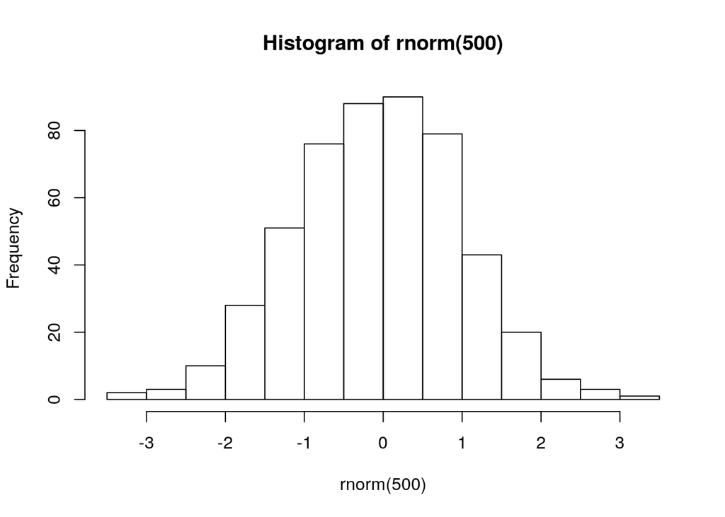

```r
hist(rnorm(500))
```

```r
x <- rnorm(1000)
print(x[1:20])
```

```
 [1] -0.75485808 -1.03586740 -0.75947108  0.59112770  0.37529982
 [6]  1.24733657  0.71193106  1.65312739  0.13263310 -0.08280947
[11]  0.61013790 -0.19659086 -1.19243194 -2.07826803 -0.63969876
[16]  0.45858636  0.70648027  0.98433861 -1.59137272  1.38627077
```

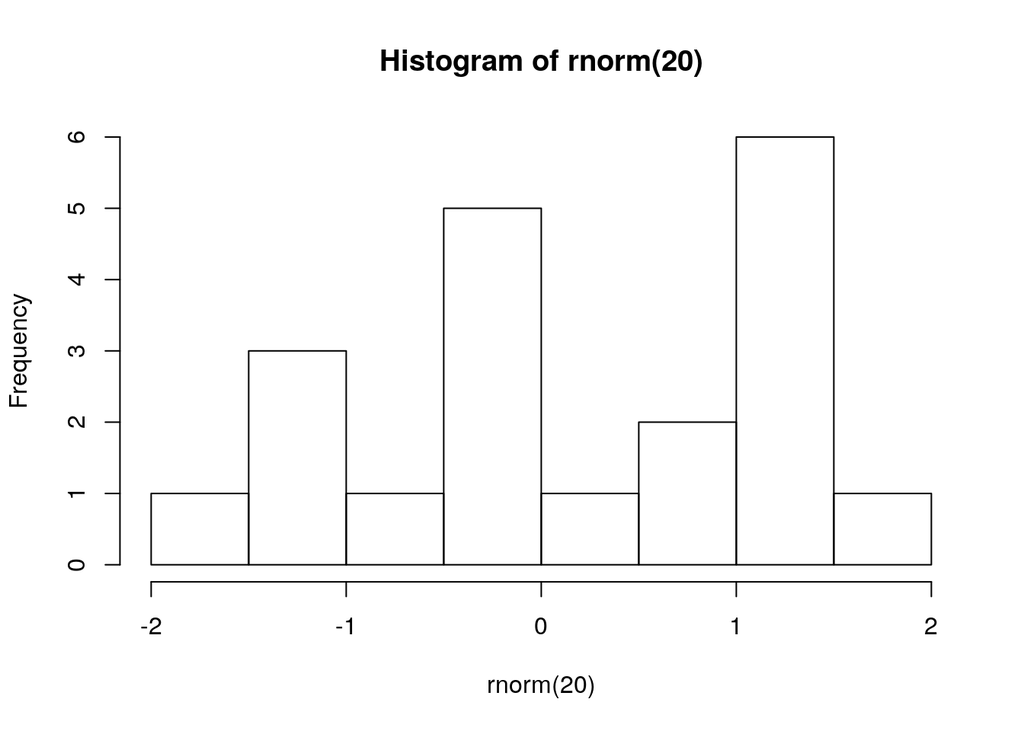

```r
hist(rnorm(20))
```

#### R code inside a callout

```r
summary(x)
```

```
    Min.  1st Qu.   Median     Mean  3rd Qu.     Max.
-3.86800 -0.66230  0.00484  0.01349  0.64510  2.82100
```

## Tables

```r
  xx <- "<table><tr><td>hipaul</td><td>zach</td></tr></table>\n"
  xx
```

```
[1] "<table><tr><td>hipaul</td><td>zach</td></tr></table>\n"
```

```r
library(rockchalk)
   set.seed(2134234)
   dat <- data.frame(x1 = rnorm(100), x2 = rnorm(100))
   dat$y1 <- 30 + 5 * rnorm(100) + 3 * dat$x1 + 4 * dat$x2
   dat$y2 <- rnorm(100) + 5 * dat$x2
   m1 <- lm(y1 ~ x1, data = dat)
   m2 <- lm(y1 ~ x2, data = dat)
   m3 <- lm(y1 ~ x1 + x2, data = dat)
   gm1 <- glm(y1 ~ x1, family = Gamma, data = dat)

or1 <- outreg(list("Amod" = m1, "Bmod" = m2, "Gmod" = m3),
title = "My Three Linear Regressions", float = FALSE, type = "html",
browse = FALSE)
```

```r
or1 <- gsub("&nbsp;"," ", or1)
or1 <- gsub("^\\ *", "", or1)
or1 <- paste(or1, collapse = "")
or1 <- gsub("\\ \\ \\ \\ \\ \\ ", " ", or1)
or1 <- gsub("\\ \\ \\ ", " ", or1)
cat(or1)
```

```r
    library(xtable)
    or2 <- xtable(summary(m1))
    print(or2, type="html")
```

|  | Estimate | Std. Error | t value | Pr(>\|t\|) |
| --- | --- | --- | --- | --- |
| (Intercept) | 30.2455 | 0.6176 | 48.97 | 0.0000 |
| x1 | 1.5455 | 0.6924 | 2.23 | 0.0279 |

Available under Created Commons license 3.0